# R Notebook

Here I experiment with creating contours of Truchet tiles after seeing some really cool examples (see: https://twitter.com/_sayo_y/status/1488504770755440640).

I will use these packages:

```r
library(imager)
```

Try function:

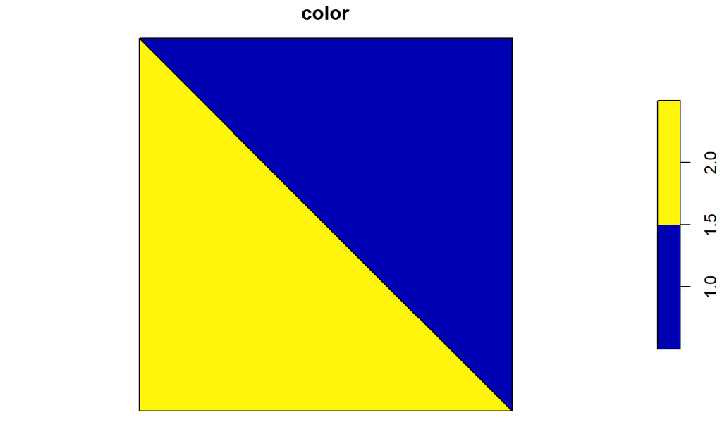

```r
st_truchet_flex(type = "Al", b = 1/2) %>%
  plot()
```

Design data frame with alternating values of b according to a checkerboard pattern. This is identical to the 2-by-2 arrangement of AC-CA called “design C” by Truchet (see p. 122 of Bosch and Colley, 2013):

```r
df <- data.frame(expand.grid(x = 1:10,
                             y = 1:10))

df <- df %>%
  # The modulus of x + y can be used to create a checkerboard pattern
  mutate(tiles = case_when((x + y) %% 2 == 0 ~ "Al",
                           (x + y) %% 2 == 1 ~ "Cl"),
         b = 1/2)
         # b = ifelse((x + y) %% 2 == 1, 1/3, 2/3))
```

Create mosaic:

```r
mosaic <- st_truchet_fm(df = df)
```

Plot:

[figure not shown]

```r
mosaic %>%
  ggplot() +
  geom_sf(aes(fill = color),
          color = "white") +
  scale_fill_distiller(direction = 1)
```

Data frame with random values of b:

```r
df <- data.frame(expand.grid(x = 1:10,
                             y = 1:10))

df <- df %>%
  # The modulus of x + y can be used to create a checkerboard pattern
  mutate(tiles = case_when((x + y) %% 2 == 0 ~ "Al",
                           (x + y) %% 2 == 1 ~ "Cl"),
         b = runif(n(), 1/3, 1/2))
```

Create mosaic:

```r
mosaic <- st_truchet_fm(df = df)
```

Plot:

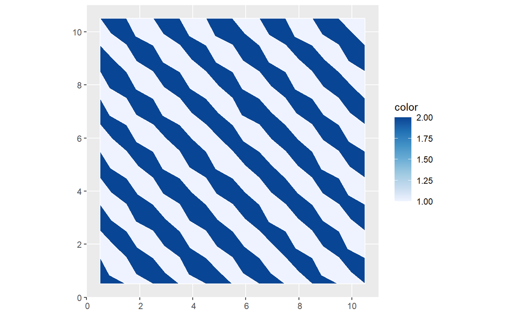

```r
mosaic %>%
  st_truchet_dissolve() %>%
  ggplot() +
  geom_sf(aes(fill = color),
          color = "white") +
  scale_fill_distiller(direction = 1)
```

“Design D” is as follows:
$$\begin{array}\\
B & A\\
C & D
\end{array}$$
Recreate this design:

```r
df <- data.frame(expand.grid(x = 1:10,
                             y = 1:10))

df <- df %>%
  # The modulus of x + y can be used to create the desired pattern
  mutate(tiles = case_when(x %% 2 == 1 & y %% 2 == 0 ~ "Bl",
                           x %% 2 == 0 & y %% 2 == 0 ~ "Al",
                           x %% 2 == 1 & y %% 2 == 1 ~ "Cl",
                           x %% 2 == 0 & y %% 2 == 1 ~ "Dl"),
         b = 1/2)
```

Create mosaic:

```r
mosaic <- st_truchet_fm(df = df)
```

Plot:

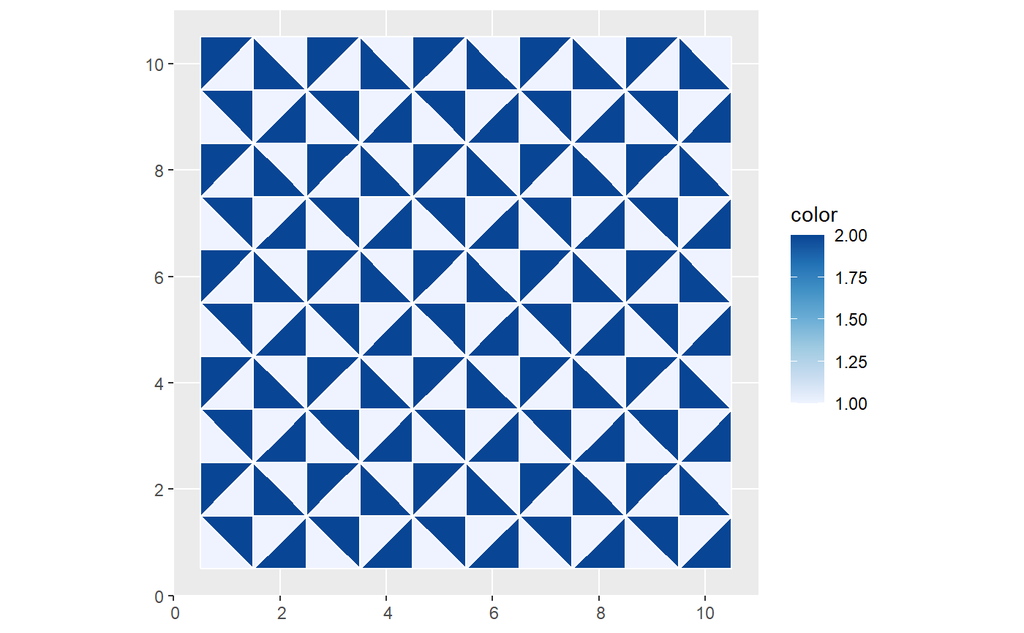

```r
ggplot() +
  geom_sf(data = mosaic,
          aes(fill = color),
          color = "white",
          size = 0.5) +
  scale_fill_distiller(direction = 1)
```

```r
df <- data.frame(expand.grid(x = 1:10,
                             y = 1:10))

df <- df %>%
  # The modulus of x + y can be used to create the desired pattern
  mutate(tiles = case_when(x %% 2 == 1 & y %% 2 == 0 ~ "Al",
                           x %% 2 == 0 & y %% 2 == 0 ~ "Dl",
                           x %% 2 == 1 & y %% 2 == 1 ~ "Bl",
                           x %% 2 == 0 & y %% 2 == 1 ~ "Cl"),
         b = 1/2)
```

Create mosaic:

```r
mosaic <- st_truchet_fm(df = df)
```

Plot (notice the difference with figure 2 in Bosch and Colley):

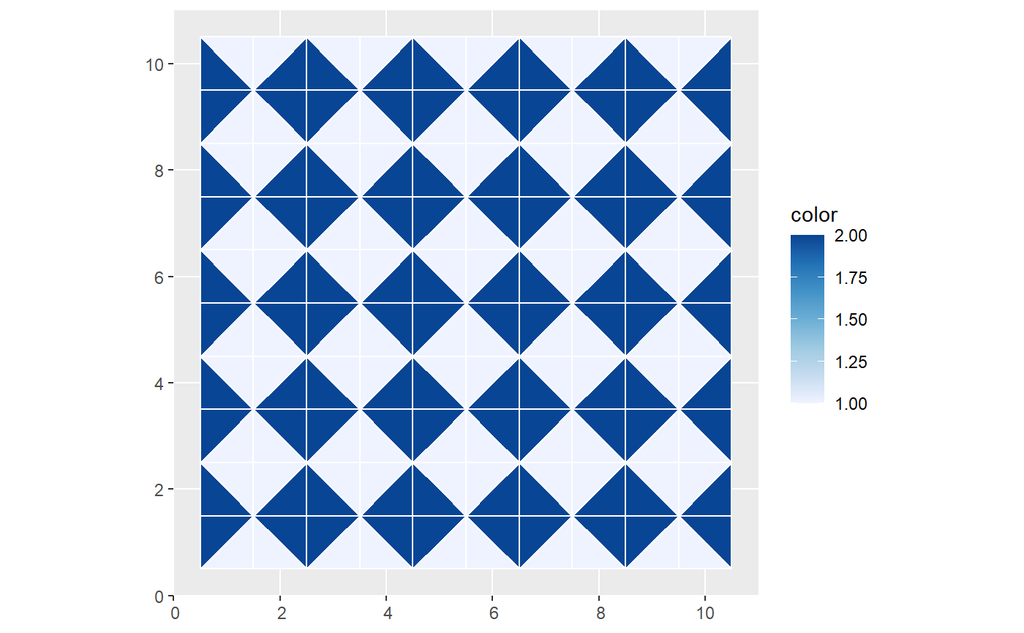

```r
ggplot() +
geom_sf(data = mosaic,
        aes(fill = color),
          color = "white",
          size = 0.5) +
  scale_fill_distiller(direction = 1)
```

Recreate this design:

```r
df <- data.frame(expand.grid(x = 1:12,
                             y = 1:12))

df <- df %>%
  mutate(tiles = case_when(y %% 4 == 1 & x %% 4 == 1 ~ "Bl",
                           y %% 4 == 1 & x %% 4 == 2 ~ "Cl",
                           y %% 4 == 1 & x %% 4 == 3 ~ "Dl",
                           y %% 4 == 1 & x %% 4 == 0 ~ "Al",
                           # Second Row
                           y %% 4 == 2 & x %% 4 == 1 ~ "Al",
                           y %% 4 == 2 & x %% 4 == 2 ~ "Dl",
                           y %% 4 == 2 & x %% 4 == 3 ~ "Cl",
                           y %% 4 == 2 & x %% 4 == 0 ~ "Bl",
                           # Third Row
                           y %% 4 == 3 & x %% 4 == 1 ~ "Dl",
                           y %% 4 == 3 & x %% 4 == 2 ~ "Al",
                           y %% 4 == 3 & x %% 4 == 3 ~ "Bl",
                           y %% 4 == 3 & x %% 4 == 0 ~ "Cl",
                           # Fourth Row
                           y %% 4 == 0 & x %% 4 == 1 ~ "Cl",
                           y %% 4 == 0 & x %% 4 == 2 ~ "Bl",
                           y %% 4 == 0 & x %% 4 == 3 ~ "Al",
                           y %% 4 == 0 & x %% 4 == 0 ~ "Dl"),
         b = 1/2)
```

Create mosaic:

```r
mosaic <- st_truchet_fm(df = df)
```

```r
ggplot() +
  geom_sf(data = mosaic,
          aes(fill = color),
          color = "white",
          size = 0.5) +
  scale_fill_distiller(direction = 1)
```

[output not shown]

“Design 1” attributed to Douat by Bosch and Colley is based on a 2 by 4 matrix:
$$\begin{array}\\
D & A & C & B\\
A & D & B & C\\
\end{array}$$

Recreate this design:

```r
df <- data.frame(expand.grid(x = 1:12,
                             y = 1:12))

df <- df %>%
  mutate(tiles = case_when(y %% 2 == 1 & x %% 4 == 1 ~ "Dl",
                           y %% 2 == 1 & x %% 4 == 2 ~ "Al",
                           y %% 2 == 1 & x %% 4 == 3 ~ "Cl",
                           y %% 2 == 1 & x %% 4 == 0 ~ "Bl",
                           # Second Row
                           y %% 2 == 0 & x %% 4 == 1 ~ "Al",
                           y %% 2 == 0 & x %% 4 == 2 ~ "Dl",
                           y %% 2 == 0 & x %% 4 == 3 ~ "Bl",
                           y %% 2 == 0 & x %% 4 == 0 ~ "Cl"),
         b = 1/2)
```

Create mosaic:

```r
mosaic <- st_truchet_fm(df = df)
```

Plot:

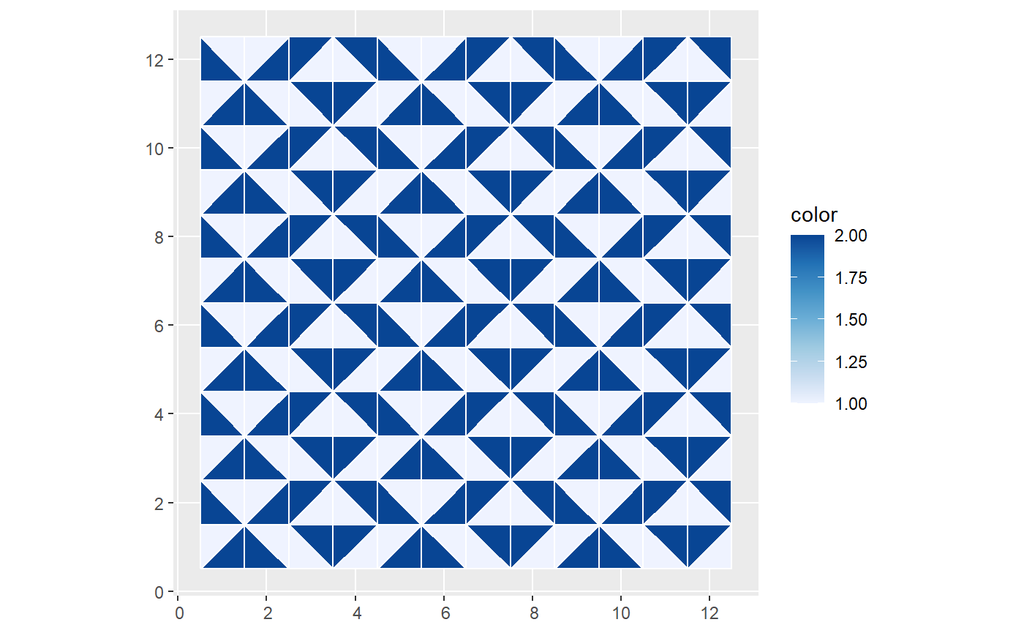

```r
ggplot() +
  geom_sf(data = mosaic,
          aes(fill = color),
          color = "white",
          size = 0.5) +
  scale_fill_distiller(direction = 1)
```

“Design 6” attributed to Douat by Bosch and Colley is based on a 4 by 4 matrix:
$$\begin{array}\\
C & B & C & B\\
B & D & A & C\\
A & C & B & D\\
D & A & D & A\\
\end{array}$$

Recreate this design:

```r
df <- data.frame(expand.grid(x = 1:12,
                             y = 1:12))

df <- df %>%
  mutate(tiles = case_when(y %% 4 == 1 & x %% 4 == 1 ~ "Cl",
                           y %% 4 == 1 & x %% 4 == 2 ~ "Bl",
                           y %% 4 == 1 & x %% 4 == 3 ~ "Cl",
                           y %% 4 == 1 & x %% 4 == 0 ~ "Bl",
                           # Second Row
                           y %% 4 == 2 & x %% 4 == 1 ~ "Bl",
                           y %% 4 == 2 & x %% 4 == 2 ~ "Dl",
                           y %% 4 == 2 & x %% 4 == 3 ~ "Al",
                           y %% 4 == 2 & x %% 4 == 0 ~ "Cl",
                           # Third Row
                           y %% 4 == 3 & x %% 4 == 1 ~ "Al",
                           y %% 4 == 3 & x %% 4 == 2 ~ "Cl",
                           y %% 4 == 3 & x %% 4 == 3 ~ "Bl",
                           y %% 4 == 3 & x %% 4 == 0 ~ "Dl",
                           # Fourth Row
                           y %% 4 == 0 & x %% 4 == 1 ~ "Dl",
                           y %% 4 == 0 & x %% 4 == 2 ~ "Al",
                           y %% 4 == 0 & x %% 4 == 3 ~ "Dl",
                           y %% 4 == 0 & x %% 4 == 0 ~ "Al"),
         b = 1/2)
```

Create mosaic:

```r
mosaic <- st_truchet_fm(df = df)
```

Plot:

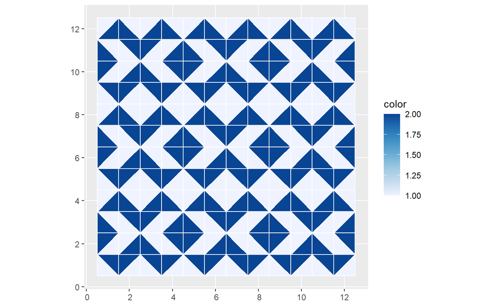

```r
ggplot() +
  geom_sf(data = mosaic,
          aes(fill = color),
          color = "white",
          size = 0.5) +
  scale_fill_distiller(direction = 1)
```

Try with buffers:

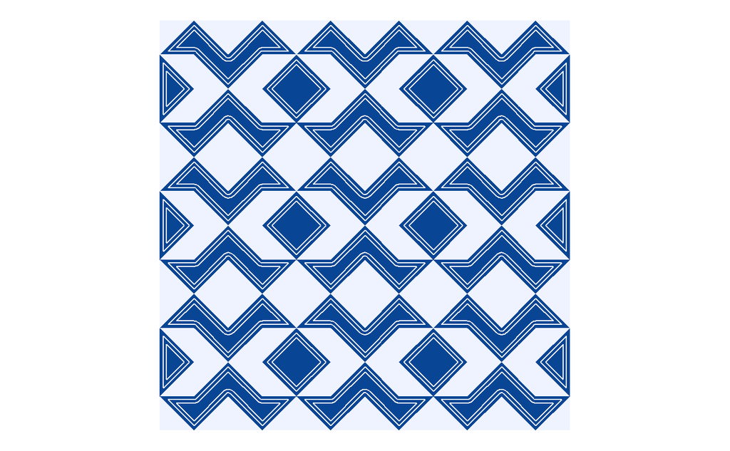

Take a 2 by 2 mosaic and assign tiles randomly:

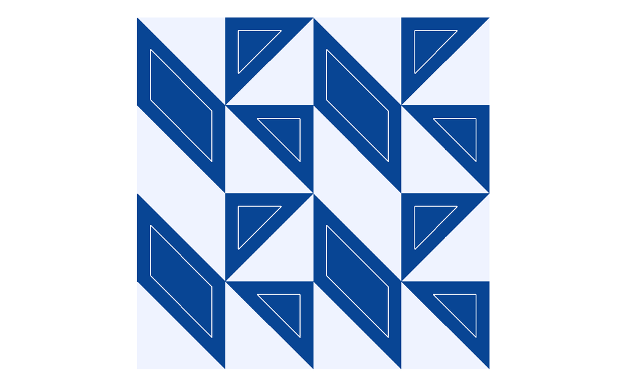

```r
# Set seed
seed <- 84467
set.seed(seed)

# Coordinates for tiles
df <- data.frame(expand.grid(x = 1:4,
                             y = 1:4))

# Randomly select tiles
tiles <- sample(c("Al", "Bl", "Cl", "Dl"), size = 4, replace = TRUE)

# Design the mosaic
df <- df %>%
  # The modulus of x + y can be used to create the desired pattern
  mutate(tiles = case_when(x %% 2 == 1 & y %% 2 == 0 ~ tiles[1],
                           x %% 2 == 0 & y %% 2 == 0 ~ tiles[2],
                           x %% 2 == 1 & y %% 2 == 1 ~ tiles[3],
                           x %% 2 == 0 & y %% 2 == 1 ~ tiles[4]),
         b = 1/2)

# Assemble mosaic
mosaic <- st_truchet_fm(df = df)

# Plot:
ggplot() +
  geom_sf(data = mosaic %>%
            st_truchet_dissolve(),
          aes(fill = color),
          color = NA,
          size = 0.5) +
  geom_sf(data = mosaic %>%
            st_truchet_dissolve() %>%
            st_buffer(dist = c(-0.15)) %>%
            filter(color == 2),
          fill = NA,
          color = "white",
          size = 0.5) +
  scale_fill_distiller(direction = 1) +
  theme_void() +
  theme(legend.position = "none")
```

```r
#ggsave(glue::glue("truchet_2x2_{seed}.png"))
```

Take a 4 by 4 mosaic and assign tiles randomly:

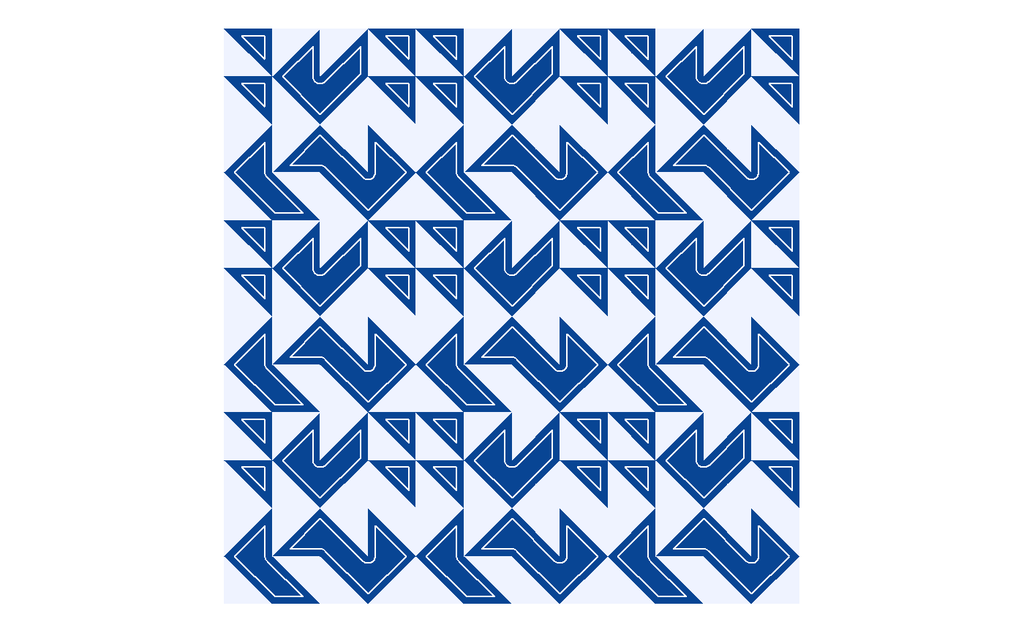

```r
# Set seed
seed <- 298265805
set.seed(seed)

# Coordinates for tiles
df <- data.frame(expand.grid(x = 1:10,
                             y = 1:10))

# Randomly select tiles
tiles_1 <- sample(c("Al", "Bl", "Cl", "Dl"), size = 4, replace = TRUE)
tiles_2 <- sample(c("Al", "Bl", "Cl", "Dl"), size = 4, replace = TRUE)
tiles_3 <- sample(c("Al", "Bl", "Cl", "Dl"), size = 4, replace = TRUE)
tiles_4 <- sample(c("Al", "Bl", "Cl", "Dl"), size = 4, replace = TRUE)

df <- data.frame(expand.grid(x = 1:12,
                             y = 1:12))

df <- df %>%
  mutate(tiles = case_when(y %% 4 == 1 & x %% 4 == 1 ~ tiles_1[1],
                           y %% 4 == 1 & x %% 4 == 2 ~ tiles_1[2],
                           y %% 4 == 1 & x %% 4 == 3 ~ tiles_1[3],
                           y %% 4 == 1 & x %% 4 == 0 ~ tiles_1[4],
                           # Second Row
                           y %% 4 == 2 & x %% 4 == 1 ~ tiles_2[1],
                           y %% 4 == 2 & x %% 4 == 2 ~ tiles_2[2],
                           y %% 4 == 2 & x %% 4 == 3 ~ tiles_2[3],
                           y %% 4 == 2 & x %% 4 == 0 ~ tiles_2[4],
                           # Third Row
                           y %% 4 == 3 & x %% 4 == 1 ~ tiles_3[1],
                           y %% 4 == 3 & x %% 4 == 2 ~ tiles_3[2],
                           y %% 4 == 3 & x %% 4 == 3 ~ tiles_3[3],
                           y %% 4 == 3 & x %% 4 == 0 ~ tiles_3[4],
                           # Fourth Row
                           y %% 4 == 0 & x %% 4 == 1 ~ tiles_4[1],
                           y %% 4 == 0 & x %% 4 == 2 ~ tiles_4[2],
                           y %% 4 == 0 & x %% 4 == 3 ~ tiles_4[3],
                           y %% 4 == 0 & x %% 4 == 0 ~ tiles_4[4]),
         b = 1/2)

# Assemble mosaic
mosaic <- st_truchet_fm(df = df)

# Plot:
ggplot() +
  geom_sf(data = mosaic %>%
            st_truchet_dissolve(),
          aes(fill = color),
          color = NA,
          size = 0.5) +
  geom_sf(data = mosaic %>%
            st_truchet_dissolve() %>%
            st_buffer(dist = c(-0.15)) %>%
            filter(color == 2),
          fill = NA,
          color = "white",
          size = 0.5) +
  scale_fill_distiller(direction = 1) +
  theme_void() +
  theme(legend.position = "none")

ggsave(glue::glue("truchet_4x4_{seed}.png"))
```

## Figurative mosaics

Load package to work with images:

```r
library(imager)
```

Read the image using `imager::load.image()`:

```r
#melville <- image_read("melville_lg.jpg")
elvis <- load.image("elvis.jpg")
```

Image info:

```r
elvis
```

```
Image. Width: 1031 pix Height: 1280 pix Depth: 1 Colour channels: 3
```

[figure not shown]

Resize image:

```r
elvis_rs <- imresize(elvis, scale = 1/10, interpolation = 6)
```

Convert to grayscale and to data frame:

```r
elvis_df <- elvis_rs %>%
  grayscale() %>%
  as.data.frame()
```

Use this data frame to design truchet mosaic:

```r
df <- elvis_df %>%
  # Reverse the y axis
  mutate(y = -(y - max(y)),
         # The modulus of x + y can be used to create a checkerboard pattern
         tiles = case_when((x + y) %% 2 == 0 ~ "Al",
                           (x + y) %% 2 == 1 ~ "Cl"),
         b = case_when((x + y) %% 2 == 0 ~ 1 - value,
                       (x + y) %% 2 == 1 ~ value))
```

```r
# Start a timer
start_time <- Sys.time()

# Assemble mosaic
mosaic <- st_truchet_fm(df = df %>% mutate(b = b * 0.99 + 0.001))

# End timer
end_time <- Sys.time()

# Calculate time
end_time - start_time
```

```
Time difference of 3.281346 mins
```

```r
ggsave("elvis-truchet.png")
```

[output not shown]

Read another image:

```r
frida <- load.image("frida.jpg")
```

Image info:

```r
frida
```

```
Image. Width: 600 pix Height: 391 pix Depth: 1 Colour channels: 3
```

[figure not shown]

```r
plot(frida)
```

```r
frida_sel <- imsub(frida,x %inr% c(109,500))
```

Resize image:

```r
frida_rs <- imresize(frida_sel, scale = 1/4, interpolation = 6)
```

Convert to grayscale and to data frame:

```r
frida_df <- frida_rs %>%
  grayscale() %>%
  as.data.frame()
```

Use this data frame to design truchet mosaic according to the pattern “Design A”:

```r
df <- frida_df %>%
  # Reverse the y axis
  mutate(y = -(y - max(y)),
         tiles = "Al",
         b = 1 - value)
```

Create mosaic:

```r
# Start a timer
start_time <- Sys.time()

# Assemble mosaic
mosaic <- st_truchet_fm(df = df %>% mutate(b = b * 0.80 + 0.001))

# End timer
end_time <- Sys.time()

# Calculate time
end_time - start_time
```

```
Time difference of 1.354234 mins
```

Plot:

[figure not shown]

```r
mosaic %>%
  ggplot() +
  geom_sf(aes(fill = color),
          color = NA) +
  scale_fill_gradientn(colors = mex.brewer("Frida")) +
  theme_void() +
  theme(legend.position = "none")

ggsave("frida-truchet-design-a.png")
```

Use this data frame to design truchet mosaic using Design C:

```r
df <- frida_df %>%
  # Reverse the y axis
  mutate(y = -(y - max(y)),
         # The modulus of x + y can be used to create a checkerboard pattern
         tiles = case_when((x + y) %% 2 == 0 ~ "Al",
                           (x + y) %% 2 == 1 ~ "Cl"),
         b = case_when((x + y) %% 2 == 0 ~ 1 - value,
                       (x + y) %% 2 == 1 ~ value))
```

Create mosaic:

```r
# Start a timer
start_time <- Sys.time()

# Assemble mosaic
mosaic <- st_truchet_fm(df = df %>% mutate(b = b * 0.80 + 0.001))

# End timer
end_time <- Sys.time()

# Calculate time
end_time - start_time
```

```
Time difference of 1.481604 mins
```

Plot:

[figure not shown]

```r
mosaic %>%
  ggplot() +
  geom_sf(aes(fill = color),
          color = NA) +
  scale_fill_gradientn(colors = mex.brewer("Frida")) +
  theme_void() +
  theme(legend.position = "none")

ggsave("frida-truchet-design-c.png")
```

Frida in Design D:

```r
df <- frida_df %>%
  # Reverse the y axis
  mutate(y = -(y - max(y)),
         # The modulus can be used to create a checkerboard pattern
         tiles = case_when(x %% 2 == 1 & y %% 2 == 0 ~ "Bl",
                           x %% 2 == 0 & y %% 2 == 0 ~ "Al",
                           x %% 2 == 1 & y %% 2 == 1 ~ "Cl",
                           x %% 2 == 0 & y %% 2 == 1 ~ "Dl"),
         b = case_when(x %% 2 == 1 & y %% 2 == 0 ~ 1 - value,
                       x %% 2 == 0 & y %% 2 == 0 ~ 1 - value,
                       x %% 2 == 1 & y %% 2 == 1 ~ value,
                       x %% 2 == 0 & y %% 2 == 1 ~ value))
```

Create mosaic:

```r
# Start a timer
start_time <- Sys.time()

# Assemble mosaic
mosaic <- st_truchet_fm(df = df %>% mutate(b = b * 0.80 + 0.001))

# End timer
end_time <- Sys.time()

# Calculate time
end_time - start_time
```

```
Time difference of 1.547333 mins
```

Plot:

[figure not shown]

```r
mosaic %>%
  ggplot() +
  geom_sf(aes(fill = color),
          color = NA) +
  scale_fill_gradientn(colors = mex.brewer("Frida")) +
  theme_void() +
  theme(legend.position = "none")

ggsave("frida-truchet-design-d.png")
```

Frida in the (mistaken) Design E:

```r
df <- frida_df %>%
  # Reverse the y axis
  mutate(y = -(y - max(y)),
         # The modulus of x + y can be used to create a checkerboard pattern
         tiles = case_when(x %% 2 == 1 & y %% 2 == 0 ~ "Al",
                           x %% 2 == 0 & y %% 2 == 0 ~ "Dl",
                           x %% 2 == 1 & y %% 2 == 1 ~ "Bl",
                           x %% 2 == 0 & y %% 2 == 1 ~ "Cl"),
         b = case_when(x %% 2 == 1 & y %% 2 == 0 ~ 1 - value,
                           x %% 2 == 0 & y %% 2 == 0 ~ value,
                           x %% 2 == 1 & y %% 2 == 1 ~ 1 - value,
                           x %% 2 == 0 & y %% 2 == 1 ~ value))
```

Create mosaic:

```r
# Start a timer
start_time <- Sys.time()

# Assemble mosaic
mosaic <- st_truchet_fm(df = df %>% mutate(b = b * 0.99 + 0.001))

# End timer
end_time <- Sys.time()

# Calculate time
end_time - start_time
```

```
Time difference of 1.532137 mins
```

Plot (notice the difference with figure 2 in Bosch and Colley):

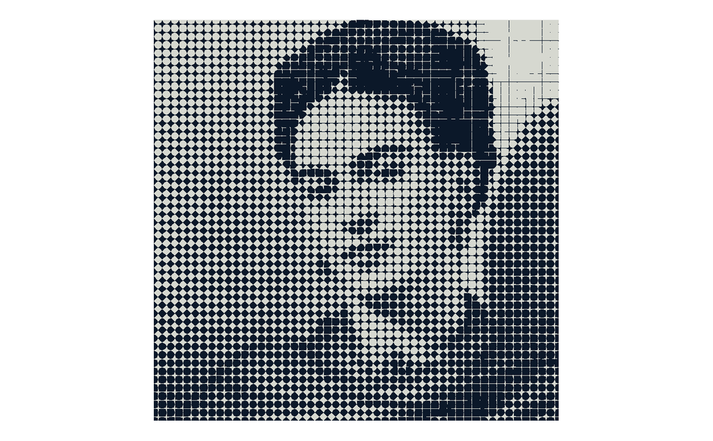

```r
mosaic %>%
  ggplot() +
  geom_sf(aes(fill = color),
          color = NA) +
  scale_fill_gradientn(colors = mex.brewer("Frida")) +
  theme_void() +
  theme(legend.position = "none")

ggsave("frida-truchet-design-wrong-e.png")
```

## Garalicious

Read another image:

```r
gara <- load.image("gara-one.jpg")
```

Image info:

```r
gara
```

```
Image. Width: 960 pix Height: 1280 pix Depth: 1 Colour channels: 3
```

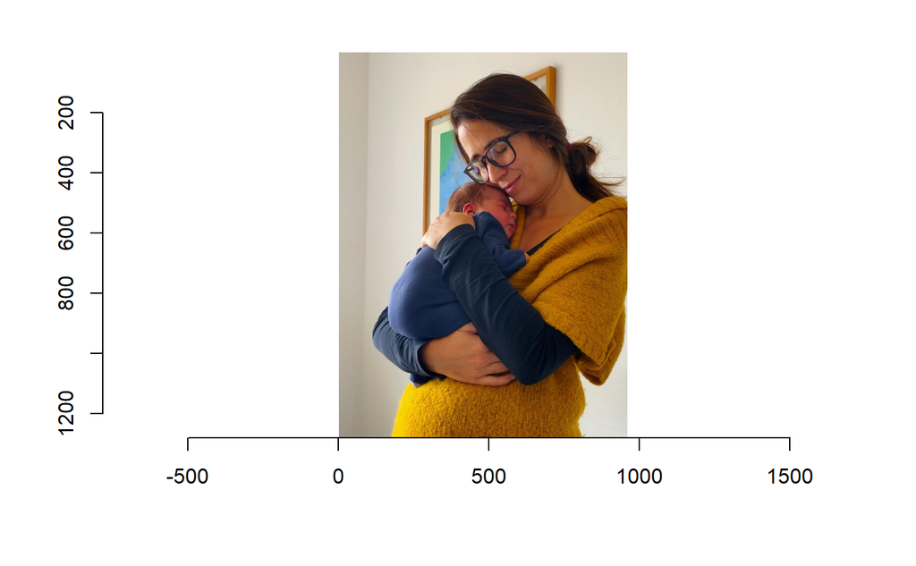

```r
plot(gara)
```

```r
gara_sel <- imsub(gara,
                   x %inr% c(250, 849),
                  y %inr% c(0, 900))
```

Resize image:

```r
gara_rs <- imresize(gara_sel, scale = 1/7, interpolation = 6)
```

Convert to grayscale and to data frame:

```r
gara_df <- gara_rs %>%
  grayscale() %>%
  as.data.frame()
```

Use this data frame to design truchet mosaic according to the pattern “Design A”:

```r
df <- gara_df %>%
  # Reverse the y axis
  mutate(y = -(y - max(y)),
         tiles = "Al",
         b = 1 - value)
```

Create mosaic:

```r
# Start a timer
start_time <- Sys.time()

# Assemble mosaic
mosaic <- st_truchet_fm(df = df %>% mutate(b = b * 0.80 + 0.001))

# End timer
end_time <- Sys.time()

# Calculate time
end_time - start_time
```

```
Time difference of 1.905942 mins
```

Plot:

[figure not shown]

```r
mosaic %>%
  ggplot() +
  geom_sf(aes(fill = color),
          color = NA) +
  scale_fill_gradientn(colors = mex.brewer("Frida")) +
  theme_void() +
  theme(legend.position = "none")

ggsave("gara-truchet-design-a.png")
```

Use this data frame to design truchet mosaic using Design C:

```r
df <- gara_df %>%
  # Reverse the y axis
  mutate(y = -(y - max(y)),
         # The modulus of x + y can be used to create a checkerboard pattern
         tiles = case_when((x + y) %% 2 == 0 ~ "Al",
                           (x + y) %% 2 == 1 ~ "Cl"),
         b = case_when((x + y) %% 2 == 0 ~ 1 - value,
                       (x + y) %% 2 == 1 ~ value))
```

Create mosaic:

```r
# Start a timer
start_time <- Sys.time()

# Assemble mosaic
mosaic <- st_truchet_fm(df = df %>% mutate(b = b * 0.80 + 0.001))

# End timer
end_time <- Sys.time()

# Calculate time
end_time - start_time
```

```
Time difference of 4.38983 mins
```

Plot:

[figure not shown]

```r
mosaic %>%
  ggplot() +
  geom_sf(aes(fill = color),
          color = NA) +
  scale_fill_gradientn(colors = mex.brewer("Frida")) +
  theme_void() +
  theme(legend.position = "none")

ggsave("gara-truchet-design-c.png")
```

Gara in Design D:

```r
df <- gara_df %>%
  # Reverse the y axis
  mutate(y = -(y - max(y)),
         # The modulus can be used to create a checkerboard pattern
         tiles = case_when(x %% 2 == 1 & y %% 2 == 0 ~ "Bl",
                           x %% 2 == 0 & y %% 2 == 0 ~ "Al",
                           x %% 2 == 1 & y %% 2 == 1 ~ "Cl",
                           x %% 2 == 0 & y %% 2 == 1 ~ "Dl"),
         b = case_when(x %% 2 == 1 & y %% 2 == 0 ~ 1 - value,
                       x %% 2 == 0 & y %% 2 == 0 ~ 1 - value,
                       x %% 2 == 1 & y %% 2 == 1 ~ value,
                       x %% 2 == 0 & y %% 2 == 1 ~ value))
```

Create mosaic:

```r
# Start a timer
start_time <- Sys.time()

# Assemble mosaic
mosaic <- st_truchet_fm(df = df %>% mutate(b = b * 0.80 + 0.001))

# End timer
end_time <- Sys.time()

# Calculate time
end_time - start_time
```

```
Time difference of 1.709566 mins
```

```r
ggsave("gara-truchet-design-d.png")
```

[output not shown]

Gara in the (mistaken) Design E:

```r
df <- gara_df %>%
  # Reverse the y axis
  mutate(y = -(y - max(y)),
         # The modulus of x + y can be used to create a checkerboard pattern
         tiles = case_when(x %% 2 == 1 & y %% 2 == 0 ~ "Al",
                           x %% 2 == 0 & y %% 2 == 0 ~ "Dl",
                           x %% 2 == 1 & y %% 2 == 1 ~ "Bl",
                           x %% 2 == 0 & y %% 2 == 1 ~ "Cl"),
         b = case_when(x %% 2 == 1 & y %% 2 == 0 ~ 1 - value,
                           x %% 2 == 0 & y %% 2 == 0 ~ value,
                           x %% 2 == 1 & y %% 2 == 1 ~ 1 - value,
                           x %% 2 == 0 & y %% 2 == 1 ~ value))
```

Create mosaic:

```r
# Start a timer
start_time <- Sys.time()

# Assemble mosaic
mosaic <- st_truchet_fm(df = df %>% mutate(b = b * 0.99 + 0.001))

# End timer
end_time <- Sys.time()

# Calculate time
end_time - start_time
```

```
Time difference of 1.420176 mins
```

```r
ggsave("gara-truchet-design-wrong-e.png")
```

[output not shown]

## Belen

Read another image:

```r
belen <- load.image("belen.jpg")
```

Image info:

```r
belen
```

```
Image. Width: 828 pix Height: 622 pix Depth: 1 Colour channels: 3
```

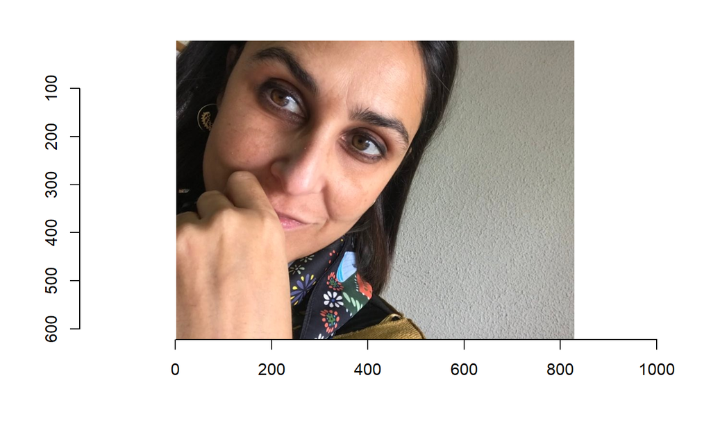

```r
plot(belen)
```

```r
belen_sel <- imsub(belen,
                   x %inr% c(100, 500),
                  y %inr% c(22, 622))
```

Resize image:

```r
belen_rs <- imresize(belen_sel, scale = 1/7, interpolation = 6)
```

Convert to grayscale and to data frame:

```r
belen_df <- belen_rs %>%
  grayscale() %>%
  as.data.frame()
```

Use this data frame to design truchet mosaic according to the pattern “Design A”:

```r
df <- belen_df %>%
  # Reverse the y axis
  mutate(y = -(y - max(y)),
         tiles = "Al",
         b = 1 - value)
```

Create mosaic:

```r
# Start a timer
start_time <- Sys.time()

# Assemble mosaic
mosaic <- st_truchet_fm(df = df %>% mutate(b = b * 0.80 + 0.001))

# End timer
end_time <- Sys.time()

# Calculate time
end_time - start_time
```

```
Time difference of 46.03055 secs
```

Plot:

[figure not shown]

```r
mosaic %>%
  ggplot() +
  geom_sf(aes(fill = color),
          color = NA) +
  #scale_fill_gradientn(colors = mex.brewer("Frida")) +
  scale_fill_distiller(direction = 1) +
  theme_void() +
  theme(legend.position = "none")

ggsave("belen-truchet-design-a.png")
```

Use this data frame to design truchet mosaic using Design C:

```r
df <- belen_df %>%
  # Reverse the y axis
  mutate(y = -(y - max(y)),
         # The modulus of x + y can be used to create a checkerboard pattern
         tiles = case_when((x + y) %% 2 == 0 ~ "Al",
                           (x + y) %% 2 == 1 ~ "Cl"),
         b = case_when((x + y) %% 2 == 0 ~ 1 - value,
                       (x + y) %% 2 == 1 ~ value))
```

Create mosaic:

```r
# Start a timer
start_time <- Sys.time()

# Assemble mosaic
mosaic <- st_truchet_fm(df = df %>% mutate(b = b * 0.80 + 0.001))

# End timer
end_time <- Sys.time()

# Calculate time
end_time - start_time
```

```
Time difference of 43.89125 secs
```

Plot:

[figure not shown]

```r
mosaic %>%
  ggplot() +
  geom_sf(aes(fill = color),
          color = NA) +
  #scale_fill_gradientn(colors = mex.brewer("Frida")) +
  scale_fill_distiller(direction = 1) +
  theme_void() +
  theme(legend.position = "none")

ggsave("belen-truchet-design-c.png")
```

Belen in Design D:

```r
df <- belen_df %>%
  # Reverse the y axis
  mutate(y = -(y - max(y)),
         # The modulus can be used to create a checkerboard pattern
         tiles = case_when(x %% 2 == 1 & y %% 2 == 0 ~ "Bl",
                           x %% 2 == 0 & y %% 2 == 0 ~ "Al",
                           x %% 2 == 1 & y %% 2 == 1 ~ "Cl",
                           x %% 2 == 0 & y %% 2 == 1 ~ "Dl"),
         b = case_when(x %% 2 == 1 & y %% 2 == 0 ~ 1 - value,
                       x %% 2 == 0 & y %% 2 == 0 ~ 1 - value,
                       x %% 2 == 1 & y %% 2 == 1 ~ value,
                       x %% 2 == 0 & y %% 2 == 1 ~ value))
```

Create mosaic:

```r
# Start a timer
start_time <- Sys.time()

# Assemble mosaic
mosaic <- st_truchet_fm(df = df %>% mutate(b = b * 0.80 + 0.001))

# End timer
end_time <- Sys.time()

# Calculate time
end_time - start_time
```

```
Time difference of 53.82335 secs
```

Plot:

[figure not shown]

```r
mosaic %>%
  ggplot() +
  geom_sf(aes(fill = color),
          color = NA) +
  #scale_fill_gradientn(colors = mex.brewer("Frida")) +
  scale_fill_distiller(direction = 1) +
  theme_void() +
  theme(legend.position = "none")

ggsave("belen-truchet-design-d.png")
```

Belen in the (mistaken) Design E:

```r
df <- belen_df %>%
  # Reverse the y axis
  mutate(y = -(y - max(y)),
         # The modulus of x + y can be used to create a checkerboard pattern
         tiles = case_when(x %% 2 == 1 & y %% 2 == 0 ~ "Al",
                           x %% 2 == 0 & y %% 2 == 0 ~ "Dl",
                           x %% 2 == 1 & y %% 2 == 1 ~ "Bl",
                           x %% 2 == 0 & y %% 2 == 1 ~ "Cl"),
         b = case_when(x %% 2 == 1 & y %% 2 == 0 ~ 1 - value,
                           x %% 2 == 0 & y %% 2 == 0 ~ value,
                           x %% 2 == 1 & y %% 2 == 1 ~ 1 - value,
                           x %% 2 == 0 & y %% 2 == 1 ~ value))
```

Create mosaic:

```r
# Start a timer
start_time <- Sys.time()

# Assemble mosaic
mosaic <- st_truchet_fm(df = df %>% mutate(b = b * 0.99 + 0.001))

# End timer
end_time <- Sys.time()

# Calculate time
end_time - start_time
```

```
Time difference of 47.78862 secs
```

Plot (notice the difference with figure 2 in Bosch and Colley):

[figure not shown]

```r
mosaic %>%
  ggplot() +
  geom_sf(aes(fill = color),
          color = NA) +
  #scale_fill_gradientn(colors = mex.brewer("Frida")) +
  scale_fill_distiller(direction = 1) +
  theme_void() +
  theme(legend.position = "none")

ggsave("belen-truchet-design-wrong-e.png")
```

Random placement of tiles?

[figure not shown]

```r
# Coordinates for tiles
df <- data.frame(expand.grid(x = 1:2,
                             y = 1:2))

# Randomly select tiles
tiles <- sample(c("Al", "Bl", "Cl", "Dl"), size = 4, replace = TRUE)

value <- 3/4
# Design the mosaic
df <- df %>%
  # The modulus of x + y can be used to create the desired pattern
  mutate(tiles = case_when(x %% 2 == 1 & y %% 2 == 0 ~ tiles[1],
                           x %% 2 == 0 & y %% 2 == 0 ~ tiles[2],
                           x %% 2 == 1 & y %% 2 == 1 ~ tiles[3],
                           x %% 2 == 0 & y %% 2 == 1 ~ tiles[4]),
         b = case_when(tiles == "Al" ~ value,
                           tiles == "Bl" ~ value,
                           tiles == "Cl" ~ 1 - value,
                           tiles == "Dl" ~ 1 - value))

# Assemble mosaic
mosaic <- st_truchet_fm(df = df)

# Plot:
ggplot() +
  geom_sf(data = mosaic,
          aes(fill = color),
          color = NA,
          size = 0.5) +
  scale_fill_distiller(direction = 1) +
  theme_void() +
  theme(legend.position = "none")
```

```r
#ggsave(glue::glue("truchet_2x2_{seed}.png"))
```

Belen with a random mosaic:

```r
# Set seed
seed <- 1085
set.seed(seed)

# Randomly select tiles
tiles <- sample(c("Al", "Bl", "Cl", "Dl"), size = 4, replace = TRUE)

value <- 3/4
# Design the mosaic
df <- belen_df %>%
  # Reverse the y axis
  mutate(y = -(y - max(y)),
         tiles = case_when(x %% 2 == 1 & y %% 2 == 0 ~ tiles[1],
                           x %% 2 == 0 & y %% 2 == 0 ~ tiles[2],
                           x %% 2 == 1 & y %% 2 == 1 ~ tiles[3],
                           x %% 2 == 0 & y %% 2 == 1 ~ tiles[4]),
         # Important! Notice the adjustment to the values to ensure that the area correctly reflects the underlying darkness value
         b = case_when(tiles == "Al" ~ 1- value,
                       tiles == "Bl" ~ 1- value,
                       tiles == "Cl" ~ value,
                       tiles == "Dl" ~ value))
```

Create mosaic:

```r
# Start a timer
start_time <- Sys.time()

# Assemble mosaic
mosaic <- st_truchet_fm(df = df %>% mutate(b = b * 0.99 + 0.001))

# End timer
end_time <- Sys.time()

# Calculate time
end_time - start_time
```

```
Time difference of 49.9552 secs
```

Plot (notice the difference with figure 2 in Bosch and Colley):

[figure not shown]

```r
mosaic %>%
  st_truchet_dissolve() %>%
  ggplot() +
  geom_sf(aes(fill = color),
          color = NA) +
  #scale_fill_gradientn(colors = mex.brewer("Frida")) +
  scale_fill_distiller(direction = 1) +
  theme_void() +
  theme(legend.position = "none")

ggsave(glue::glue("belen-truchet-{seed}.png"))
```

Random placement of tiles?

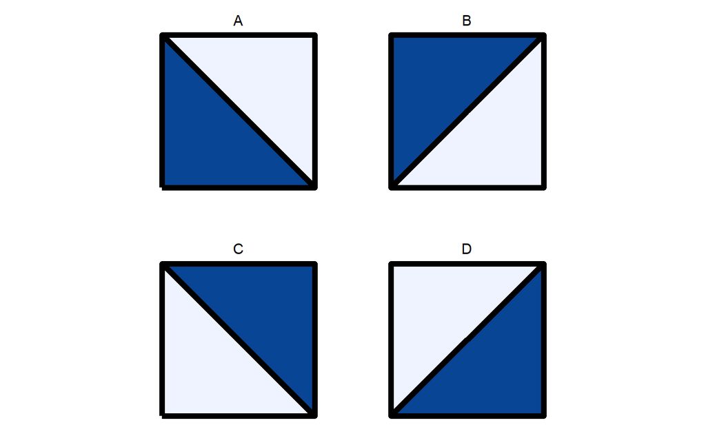

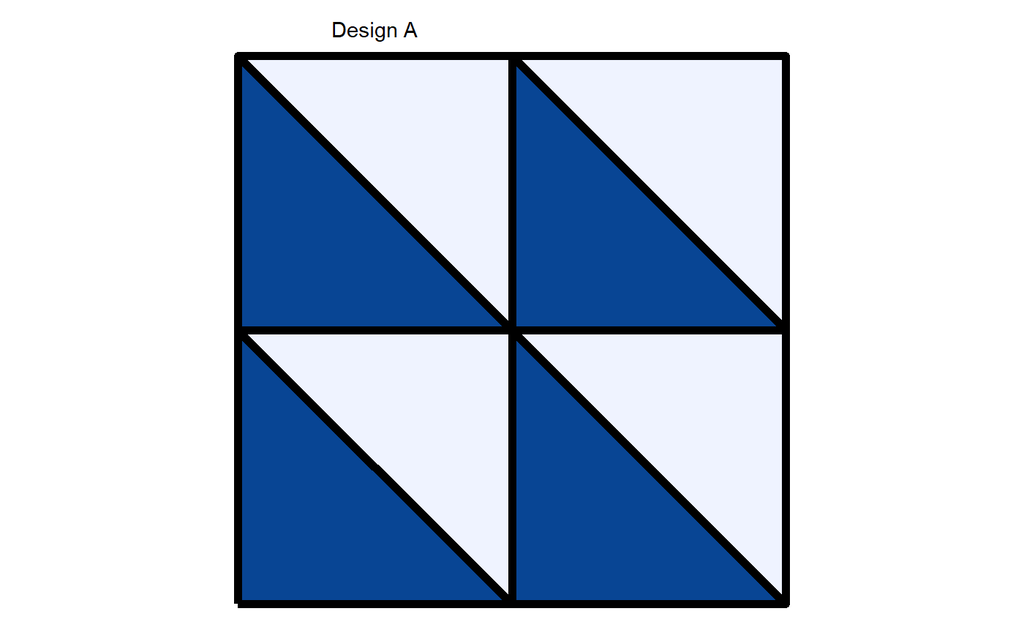

```r
# Tiles types
tile_types <- data.frame(type = c("Al", "Al", "Al", "Al")) %>%
  mutate(x = c(1, 2, 1, 2),
         y = c(2, 2, 1, 1),
         b = 1/2)

# Elements for assembling the mosaic
x_c <- tile_types$x
y_c <- tile_types$y
type <- as.character(tile_types$type)
b <- tile_types$b

pmap_dfr(list(x_c, y_c, type, b), st_truchet_flex) %>%
  ggplot() +
  geom_sf(aes(fill = color),
          color = "black",
          size = 2) +
  geom_text(data = tile_types,
            aes(x = x,
                y = y,
                label = c("Design A", "", "", "")),
            nudge_y = 0.6) +
  scale_fill_distiller(direction = 1) +
  theme_void() +
  theme(legend.position = "none")
```

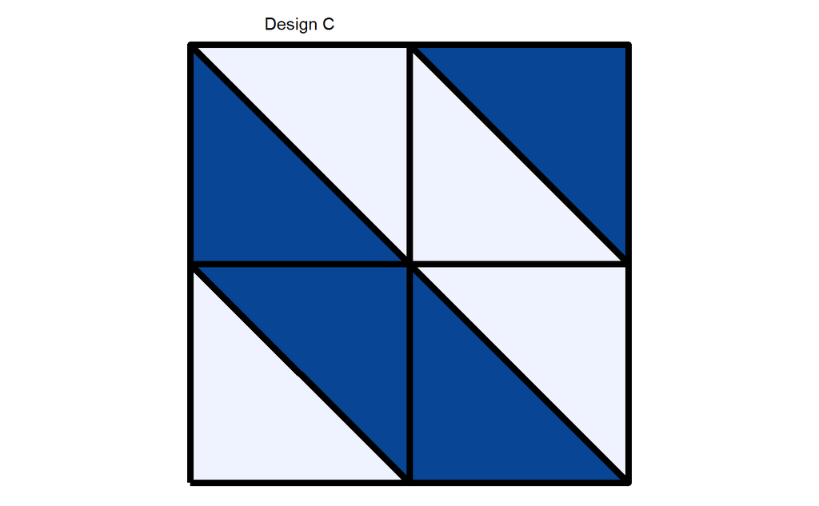

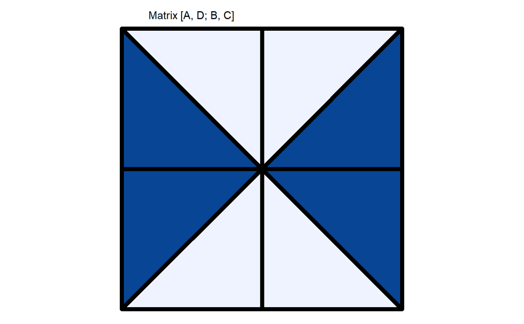

```r
# Tiles types
tile_types <- data.frame(type = c("Al", "Dl", "Bl", "Cl")) %>%
  mutate(x = c(1, 2, 1, 2),
         y = c(2, 2, 1, 1),
         b = 1/2)

# Elements for assembling the mosaic
x_c <- tile_types$x
y_c <- tile_types$y
type <- as.character(tile_types$type)
b <- tile_types$b

pmap_dfr(list(x_c, y_c, type, b), st_truchet_flex) %>%
  ggplot() +
  geom_sf(aes(fill = color),
          color = "black",
          size = 2) +
  geom_text(data = tile_types,
            aes(x = x,
                y = y,
                label = c("Matrix [A, D; B, C]", "", "", "")),
            nudge_y = 0.6) +
  scale_fill_distiller(direction = 1) +
  theme_void() +
  theme(legend.position = "none")
```

```r
df <- data.frame(expand.grid(x = 1:10,
y = 1:10))

df <- df %>%
# The modulus of x + y can be used to create a checkerboard pattern
mutate(tiles = sample(c("Al", "Bl"), n(), replace = TRUE),
b = runif(n(), 0, 1))
```

Create mosaic and join coordinates. The coordinates can be used to modify the color settings according to a checkerboard pattern:

```r
mosaic <- st_truchet_fm(df = df)
```

```r
mosaic %>%
st_truchet_dissolve() %>%
ggplot() +
geom_sf(aes(fill = color),
color = "white")
```

[output not shown]

```r
ggplot() +
geom_sf(data = mosaic %>%
st_truchet_dissolve() %>%
mutate(id = sample(1:n(),
n())),
aes(fill = id),
color = "black",
size = 0.5) +
geom_sf(data = mosaic %>%
st_truchet_dissolve() %>%
st_buffer(dist = c(-0.1, -0.2)) %>%
mutate(id = sample(1:n(),
n())),
aes(fill = id),
color = "black",
size = 0.5) +
scale_fill_gradientn(colors = mex.brewer("Revolucion")) +
theme_void() +
theme(legend.position = "none")
```

[output not shown]

```r
ggplot() +
geom_sf(data = mosaic %>%
st_truchet_dissolve() %>%
mutate(id = sample(1:n(),
n())),
aes(fill = id),
color = "black",
size = 0.5) +
geom_sf(data = mosaic %>%
st_truchet_dissolve() %>%
st_buffer(dist = c(-0.1)) %>%
mutate(id = sample(1:n(),
n())),
aes(fill = id),
color = "black",
size = 0.5) +
geom_sf(data = mosaic %>%
st_truchet_dissolve() %>%
st_buffer(dist = c(-0.2)) %>%
mutate(id = sample(1:n(),
n())),
aes(fill = id),
color = "black",
size = 0.5) +
scale_fill_gradientn(colors = mex.brewer("Revolucion")) +
theme_void() +
theme(legend.position = "none")

ggsave("flex-tiles-random-revolucion-buffers.png")
```

[output not shown]